# 3.4 with Insurance dataset

[Link](https://www.kaggle.com/datasets/mirichoi0218/insurance/) to dataset.

Need to be aware of that a 0 coeff does on categorical variables (it changes the meaning of the intercept)

```r
df <- read.csv("insurance.csv")
# clean things up so summary works as expected
df$sex = as.factor(df$sex)
df$smoker = as.factor(df$smoker)
df$region = as.factor(df$region)
summary(df)
```

```
##       age            sex           bmi           children     smoker
##  Min.   :18.00   female:662   Min.   :15.96   Min.   :0.000   no :1064
##  1st Qu.:27.00   male  :676   1st Qu.:26.30   1st Qu.:0.000   yes: 274
##  Median :39.00                Median :30.40   Median :1.000
##  Mean   :39.21                Mean   :30.66   Mean   :1.095
##  3rd Qu.:51.00                3rd Qu.:34.69   3rd Qu.:2.000
##  Max.   :64.00                Max.   :53.13   Max.   :5.000
##        region       charges
##  northeast:324   Min.   : 1122
##  northwest:325   1st Qu.: 4740
##  southeast:364   Median : 9382
##  southwest:325   Mean   :13270
##                  3rd Qu.:16640
##                  Max.   :63770
```

Data set is roughly equal gender-wise and per region, thought the southeast is a little bit more represented.

Median charges is 9382 but max is 63770 indicating we have a few large ones.

## Q1: Is there a relationship between charges and the factors presented here?

We do this by: 1. fitting a multiple linear regression model 2. and testing the null hypothesis (that all coefficients are 0)

We can then use the F-statistic and corresponding p-value to decide.

```r
lm.fit <- lm(charges ~ ., data=df)
summary(lm.fit)
```

```
##
## Call:
## lm(formula = charges ~ ., data = df)
##
## Residuals:
##      Min       1Q   Median       3Q      Max
## -11304.9  -2848.1   -982.1   1393.9  29992.8
##
## Coefficients:
##                 Estimate Std. Error t value Pr(>|t|)
## (Intercept)     -11938.5      987.8 -12.086  < 2e-16 ***
## age                256.9       11.9  21.587  < 2e-16 ***
## sexmale           -131.3      332.9  -0.394 0.693348
## bmi                339.2       28.6  11.860  < 2e-16 ***
## children           475.5      137.8   3.451 0.000577 ***
## smokeryes        23848.5      413.1  57.723  < 2e-16 ***
## regionnorthwest   -353.0      476.3  -0.741 0.458769
## regionsoutheast  -1035.0      478.7  -2.162 0.030782 *
## regionsouthwest   -960.0      477.9  -2.009 0.044765 *
## ---
## Signif. codes:  0 '***' 0.001 '**' 0.01 '*' 0.05 '.' 0.1 ' ' 1
##
## Residual standard error: 6062 on 1329 degrees of freedom
## Multiple R-squared:  0.7509, Adjusted R-squared:  0.7494
## F-statistic: 500.8 on 8 and 1329 DF,  p-value: < 2.2e-16
```

So `F-statistic: 500.8 on 8 and 1329 DF, p-value: < 2.2e-16` which indicates we can safely reject the null hypothesis.

## Q2: How strong is the relationship?

RSE is 6062! Versus the mean charge of 13270 - that’s about 46%. How does that help?

R^2 tells us the predictors explain about 75% of the variance we’re seeing.

## Q4: How large is the association between each (significant) predictor and charges?

```r
confint(lm.fit)
```

```
##                       2.5 %       97.5 %
## (Intercept)     -13876.3934 -10000.68373
## age                233.5138    280.19893
## sexmale           -784.4703    521.84155
## bmi                283.0884    395.29848
## children           205.1633    745.83780
## smokeryes        23038.0307  24659.03838
## regionnorthwest  -1287.2982    581.37040
## regionsoutheast  -1974.0968    -95.94733
## regionsouthwest  -1897.6364    -22.46560
```

Large intervals containing zero can be signs of collinearity. Let’s compute the VIF for each var:

```r
library(car)
vif(lm.fit)
```

```
##              GVIF Df GVIF^(1/(2*Df))
## age      1.016822  1        1.008376
## sex      1.008900  1        1.004440
## bmi      1.106630  1        1.051965
## children 1.004011  1        1.002003
## smoker   1.012074  1        1.006019
## region   1.098893  3        1.015841
```

We can also do separate linear regressions:

```r
lm.fitAge <- lm(charges ~ age, data=df)
summary(lm.fitAge)
```

```
##
## Call:
## lm(formula = charges ~ age, data = df)
##
## Residuals:
##    Min     1Q Median     3Q    Max
##  -8059  -6671  -5939   5440  47829
##
## Coefficients:
##             Estimate Std. Error t value Pr(>|t|)
## (Intercept)   3165.9      937.1   3.378 0.000751 ***
## age            257.7       22.5  11.453  < 2e-16 ***
## ---
## Signif. codes:  0 '***' 0.001 '**' 0.01 '*' 0.05 '.' 0.1 ' ' 1
##
## Residual standard error: 11560 on 1336 degrees of freedom
## Multiple R-squared:  0.08941,    Adjusted R-squared:  0.08872
## F-statistic: 131.2 on 1 and 1336 DF,  p-value: < 2.2e-16
```

Let’s do gender:

```r
lm.fitSex <- lm(charges ~ sex, data=df)
summary(lm.fitSex)
```

```
##
## Call:
## lm(formula = charges ~ sex, data = df)
##
## Residuals:
##    Min     1Q Median     3Q    Max
## -12835  -8435  -3980   3476  51201
##
## Coefficients:
##             Estimate Std. Error t value Pr(>|t|)
## (Intercept)  12569.6      470.1  26.740   <2e-16 ***
## sexmale       1387.2      661.3   2.098   0.0361 *
## ---
## Signif. codes:  0 '***' 0.001 '**' 0.01 '*' 0.05 '.' 0.1 ' ' 1
##
## Residual standard error: 12090 on 1336 degrees of freedom
## Multiple R-squared:  0.003282,   Adjusted R-squared:  0.002536
## F-statistic:   4.4 on 1 and 1336 DF,  p-value: 0.03613
```

## Q5: How accurately can we predict future charges?

Here we need a *prediction** interval for an individual response, or a *confidence* interval for an average response.

## Q6: Is the relationhsip linear

Let’s plot the residuals:

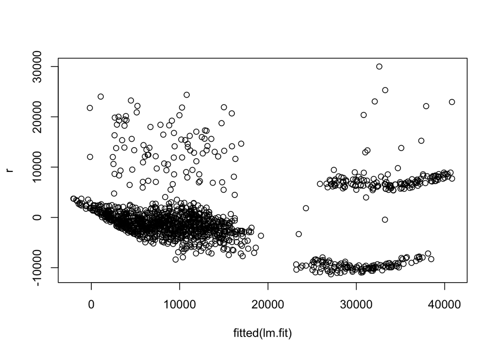

```r
r <- resid(lm.fit)
plot(fitted(lm.fit), r)
```

There are 3 distinct clusters - with one larger one. This indicates some non-linear effect!

For argument’s sake, let’s do a `pplot` on correlation and we can make a guess:

```r
library(GGally)
```

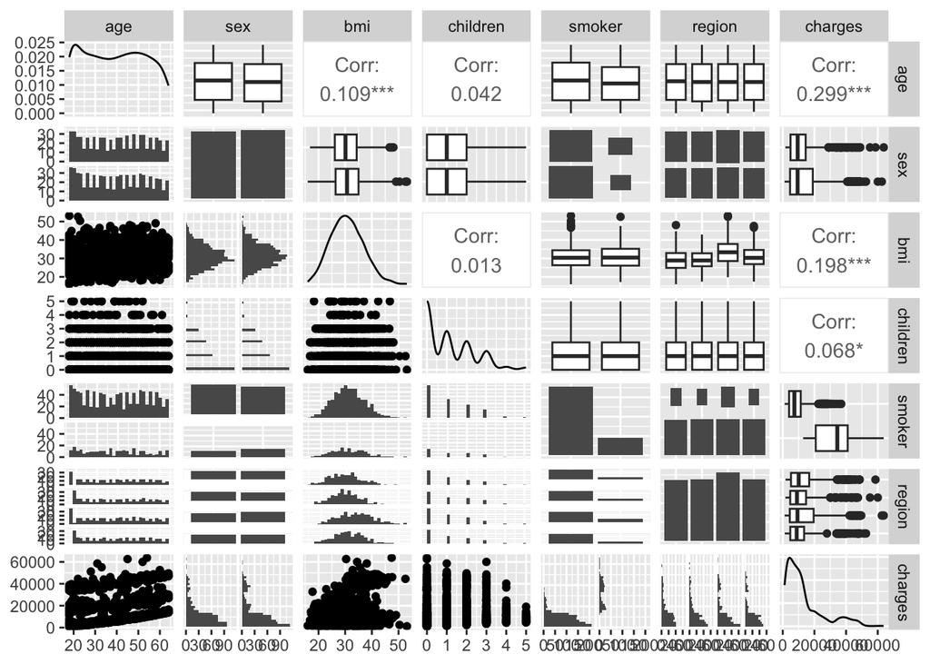

```r
ggpairs(df)
```

Let’s try with a transformation of `bmi`:

```r
lm.fitBmiExp <- lm(charges ~ bmi + I(bmi^2) + I(bmi^3), data=df)
summary(lm.fitBmiExp)
```

```
##
## Call:
## lm(formula = charges ~ bmi + I(bmi^2) + I(bmi^3), data = df)
##
## Residuals:
##    Min     1Q Median     3Q    Max
## -16408  -8088  -3912   4755  49349
##
## Coefficients:
##               Estimate Std. Error t value Pr(>|t|)
## (Intercept) 21762.8939 21335.3915   1.020    0.308
## bmi         -1858.8972  2061.8005  -0.902    0.367
## I(bmi^2)       78.4798    64.7029   1.213    0.225
## I(bmi^3)       -0.8727     0.6599  -1.322    0.186
##
## Residual standard error: 11870 on 1334 degrees of freedom
## Multiple R-squared:  0.04138,    Adjusted R-squared:  0.03922
## F-statistic: 19.19 on 3 and 1334 DF,  p-value: 3.468e-12
```

Meh. Maybe `bmi` isn’t such a great indicator of charges?

## Q7: Is there synergy among the predictors?

Let’s try an interaction term!

```r
lm.fitInter <- lm(charges ~ age + bmi + age*bmi, data=df)
summary(lm.fitInter)
```

```
##
## Call:
## lm(formula = charges ~ age + bmi + age * bmi, data = df)
##
## Residuals:
##    Min     1Q Median     3Q    Max
## -15534  -7030  -5118   7234  47992
##
## Coefficients:
##              Estimate Std. Error t value Pr(>|t|)
## (Intercept) -9162.555   4633.918  -1.977  0.04822 *
## age           313.657    114.663   2.735  0.00631 **
## bmi           422.247    149.134   2.831  0.00471 **
## age:bmi        -2.321      3.640  -0.638  0.52376
## ---
## Signif. codes:  0 '***' 0.001 '**' 0.01 '*' 0.05 '.' 0.1 ' ' 1
##
## Residual standard error: 11390 on 1334 degrees of freedom
## Multiple R-squared:  0.1175, Adjusted R-squared:  0.1155
## F-statistic: 59.18 on 3 and 1334 DF,  p-value: < 2.2e-16
```

No dice either?